# Task 2: Lizard Length to Weight NLS

Claire Meuter

2023-02-12

```r
knitr::opts_chunk$set(echo = TRUE, warning = FALSE, message = FALSE)
library(tidyverse)
library(broom)
library(here)
library(Metrics)
library(kableExtra)
```

```r
#read in the data
lizards <- read_csv(here("lizards.csv"))
```

This rmd wrangles, explores, and models data from lizard traps in the Jornada Basin LTER site.

Source: Lightfoot, D. and W.G. Whitford. 2020. Lizard pitfall trap data from 11 NPP study locations at the Jornada Basin LTER site, 1989-2006 ver 37. Environmental Data Initiative. https://doi.org/10.6073/pasta/4a6e258fb49c31e222ecbbcfd128967f

### 1. Select model

Fit a snout length to weight model of the following form to all lizards in your dataframe.
$$\begin{equation}
W=a(SVL)^b
\end{equation}$$

Let’s create a function in R that represents this equation

```r
liz_func <- function(a, b, svl){
  weight <- a*(svl^b)
  return(weight)
}
```

### 1a. Making an intial guess

Weight is given by W, snout to vent length by SVL, and a and b are the parameters that need to be fitted.

```r
# OLS regression on log-transformed model
# Since we know the model is exponential in nature, we could log transform the data. If we do a standard OLS regression on the log transformed data, we can get approximations of the parameters from the regression coefficients

guess_model <- lm(log(lizards$weight) ~ log(lizards$SV_length), data = lizards)


#c. Using the coefficients function, we can then supply the NLS start list with the regression coefficients. Hint: Because you log transformed the data, you will have to mathematically transform the intercept coefficient to get the guess for parameter a.

#Now I can look at what my coefficients look like for the guess model:
#coefficients(guess_model)

#assign guesses for parameters a and b
a <- exp((guess_model$coefficients[1]))
b <- guess_model$coefficients[2]
```

### 2. Run NLS

```r
#run nls
lizards_nls <- nls(weight ~ liz_func(a, b, SV_length),
                   data = lizards,
                   start = list(a = a, b = b))
#return results in tidy table
lizards_nls_tidy <- tidy(lizards_nls)

lizards_nls_tidy %>%
  kable(caption= "Table 1: NLS results",
        col.names = c("Parameter",
                      "Coefficient",
                      "Standard Error",
                      "Statistic",
                      "P-Value")) %>%
  kable_styling(full_width = FALSE,
                bootstrap_options = "striped",
                position = "left")
```

Table 1: NLS results

| Parameter | Coefficient | Standard Error | Statistic | P-Value |
| --- | --- | --- | --- | --- |
| a | 0.0001073 | 0.0000091 | 11.77374 | 0 |
| b | 2.7209866 | 0.0196796 | 138.26425 | 0 |

Now I can predict weight based off this model, and display the results in plot.

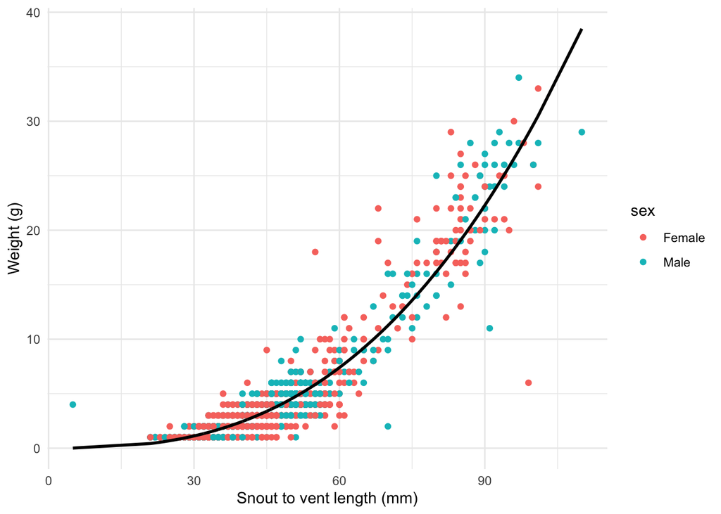

```r
#run predictions of weight
lizards_pred <- lizards %>%
  mutate(predict = predict(lizards_nls, newdata=.))

#plot how well weight prediction matches actual weight
ggplot(data = lizards_pred) +
  #include true weight pts
  geom_point(aes(x = SV_length, y = weight, color = sex)) +
  scale_color_discrete(labels = c("Female", "Male")) +
  #add our prediction data
  geom_line(aes(x = SV_length, y = predict),
            color = "black",
            size = 1) +
  labs(x = "Snout to vent length (mm)",
       y = "Weight (g)") +
  theme_minimal()
```

**Figure 1.** Snout to vent lengths (mm) and body weights (g) for male and female lizards. Female observations are in red, and male observations in blue. The observation points are overlaid with a line representing the fit of the NLS predicted model.

### 3. Filtering for Male Western Whiptail lizard (*C. tigrisatus*)

```r
#creating new data subset from lizards data
lizards_c <- lizards %>%
  filter(spp == "CNTI", #data code for C. tigrisatus
         sex == "M")

# now we can recreate what we did above, but only with C. tigrisatus
# intial guess model
guess_model_c <- lm(log(lizards_c$weight) ~ log(lizards_c$SV_length), data = lizards_c)

#explore my OLS coefficients
coefficients(guess_model_c)
```

```
##              (Intercept) log(lizards_c$SV_length)
##                -9.023963                 2.698108
```

```r
#assign guesses for parameters a and b
a_c <- exp((guess_model_c$coefficients[1]))
b_c <- guess_model_c$coefficients[2]

# run NLS
lizards_nls_c <- nls(weight ~ liz_func(a, b, SV_length),
                   data = lizards_c,
                   start = list(a = a_c, b = b_c))
#return results in tidy table
lizards_nls_c_tidy <- tidy(lizards_nls_c)

lizards_nls_c_tidy %>%
  kable(caption= "Table 1: NLS results",
        col.names = c("Parameter",
                      "Coefficient",
                      "Standard Error",
                      "Statistic",
                      "P-Value")) %>%
  kable_styling(full_width = FALSE,
                bootstrap_options = "striped",
                position = "left")
```

Table 1: NLS results

| Parameter | Coefficient | Standard Error | Statistic | P-Value |
| --- | --- | --- | --- | --- |
| a | 0.0005316 | 0.0004288 | 1.239687 | 0.2192313 |
| b | 2.3683013 | 0.1800348 | 13.154689 | 0.0000000 |

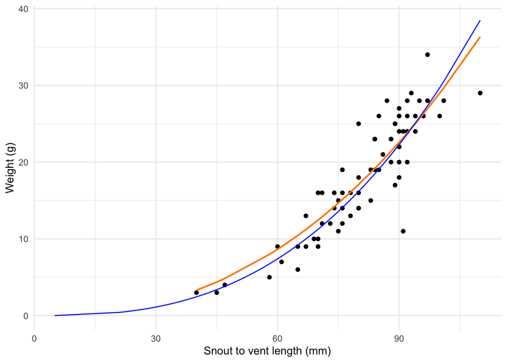

```r
#predict the weight based on model
#run predictions of weight
lizards_pred_c <- lizards_c %>%
  mutate(predict = predict(lizards_nls_c, newdata=.))


#getting RMSE for predictions
lizards_rmse <- data.frame(rmse_c = rmse(lizards_pred_c$weight,
                                            lizards_pred_c$predict),
                           rmse_cnti_v_gen = rmse(lizards_pred_c$weight,
                                                  lizards_pred$predict),
                           rmse_gen = rmse(lizards_pred$weight,
                                           lizards_pred$predict))

#plot how well weight prediction (species specific and general model)matches actual weight
ggplot(data = lizards_pred_c) +
  #include true weight pts
  geom_point(aes(x = SV_length, y = weight), color = "black") +
  #add our prediction data for species specific model
  geom_line(aes(x = SV_length, y = predict),
            color = "darkorange",
            size = .8)  +
  #line for general nls model
  geom_line(data = lizards_pred,
            aes(x = SV_length,
                y = predict),
            color = "blue") +
  labs(x = "Snout to vent length (mm)",
       y = "Weight (g)") +
  theme_minimal()
```

**Figure 1.** Snout to vent lengths (mm) and body weights (g) for male *C. tigrisatus*. The orange line displays the fit of the *C. tigrisatus* species-specific NLS model, which has an RMSE of 3.349 g.The blue line represents the general NLS model for all species of lizards, which has an RMSE of 1.563 g. Because the general model has a lower RMSE, we would want to use that model.